# Data Analytics

Salman

17/01/2022

### Session Info

Best efforts have been made to make the research as much reproducible as possible. However, it was beyond my skills set to code the process of extracting and merging the data from various data.worldbank.org links. All the data files from where the compiled data was created can be found in my [github repository](https://github.com/virani1997/Data-Analytics-Project), along with the compiled excel data file.

```r
getwd()
```

```
## [1] "D:/Masters/Semester 1/Data Analytics/Final Project/Data-Analytics-Project"
```

### Load Packages

```r
library(xlsx)
library(dplyr)
library(car)
```

### Load and Process Data

```r
data <- read.xlsx("Compiled Data.xlsx", sheetIndex = 1, startRow = 11)
names(data)
```

```
## [1] "Years"   "fdi"     "dom.cre" "inf"     "exp"     "imp"
```

```r
str(data)
```

```
## 'data.frame':    61 obs. of  6 variables:
##  $ Years  : chr  "1960" "1961" "1962" "1963" ...
##  $ fdi    : num  NA NA NA NA NA NA NA NA NA NA ...
##  $ dom.cre: num  11 12 15 17.4 21.7 ...
##  $ inf    : num  6.947 1.64 -0.516 1.456 4.18 ...
##  $ exp    : num  4.00e+08 4.24e+08 4.07e+08 4.07e+08 4.69e+08 5.50e+08 6.34e+08 6.80e+08 2.92e+08 3.32e+08 ...
##  $ imp    : num  8.27e+08 5.94e+08 8.34e+08 9.85e+08 1.07e+09 ...
```

```r
subset_data <- subset(data, Years >= 1970 & Years <= 2019)
```

### Descriptive Statistics

We see very low FDI, net inflows, in Pakistan before 1990. In 1990s the FDI started to increase to noticeable levels due to the changes in Pakistan trade policies to attract more foreign direct investments. These included better investment infrastructure and lesser constraints imposed due to bureaucracy. We also noticed a reductions in some tax levels for foreign investors after 1990s. Pakistan has shown an overall increasing trend in the FDI inflows, however we see fluctuations throughout the years we have taken into consideration in our study. One major factor can be attributed to the high political instability in Pakistan. Every four years when the government changes, we observe drastic changes in policies. Such changes in policies after every government tenure discourages long term investors. A very unusual fluctuation is shown during 2007-2009 period. These changes can be attributed to the boom and bust cycle of global financial crisis. FDI inflows, Merchandise Exports and Merchandise Imports have shown increasing trend. These values have indeed increased as the values are accounted for in US dollars and throughout these years Pakistan’s currency has depreciated a lot. Inflation has fluctuated a lot between the years with above 10% in 2019 compared to around 5% in 1970. In case of Pakistan, the basket of goods that is analysed to measure inflation rates includes food and non-alcoholic beverages (35 percent of total weight); housing, water, electricity, gas and fuels (29 percent); clothing and footwear (8 percent) and transport (7 percent). The index also includes furnishings and household equipment (4 percent), education (4 percent), communication (3 percent) and health (2 percent). The remaining 8 percent is composed by: recreation and culture, restaurants and hotels, alcoholic beverages and tobacco and other goods and services. These statistics are taken from tradingeconomics.com. Domestic Credit (% of GDP) has shown a slight declining trend in recent years.

```r
summary(subset_data)
```

```
##     Years                fdi                dom.cre           inf
##  Length:50          Min.   :  -4000000   Min.   :15.39   Min.   : 2.529
##  Class :character   1st Qu.:  63683017   1st Qu.:20.18   1st Qu.: 5.225
##  Mode  :character   Median : 363278479   Median :24.10   Median : 7.768
##                     Mean   : 948393551   Mean   :23.08   Mean   : 8.851
##                     3rd Qu.:1331250000   3rd Qu.:25.47   3rd Qu.:11.176
##                     Max.   :5590000000   Max.   :29.79   Max.   :26.663
##       exp                 imp
##  Min.   :4.490e+08   Min.   :6.080e+08
##  1st Qu.:2.648e+09   1st Qu.:5.397e+09
##  Median :7.678e+09   Median :9.440e+09
##  Mean   :9.911e+09   Mean   :1.761e+10
##  3rd Qu.:1.737e+10   3rd Qu.:3.121e+10
##  Max.   :2.538e+10   Max.   :6.008e+10
```

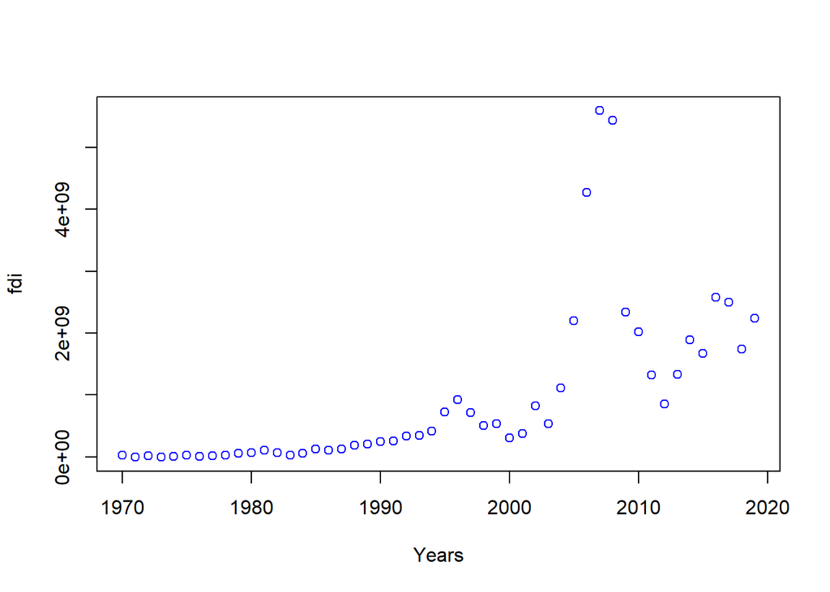

```r
with(subset_data, plot(Years,fdi, col = "blue"))
```

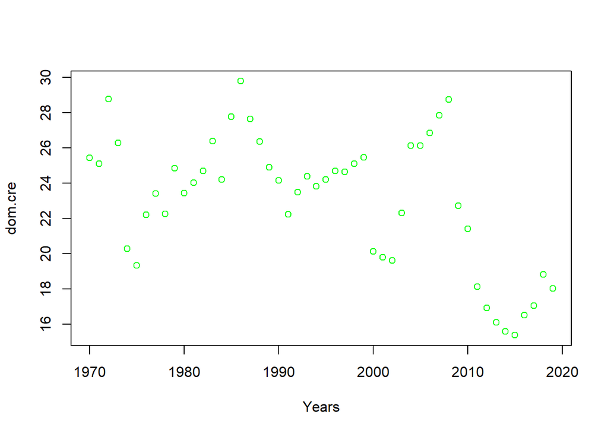

```r
with(subset_data, plot(Years,dom.cre, col = "green"))
```

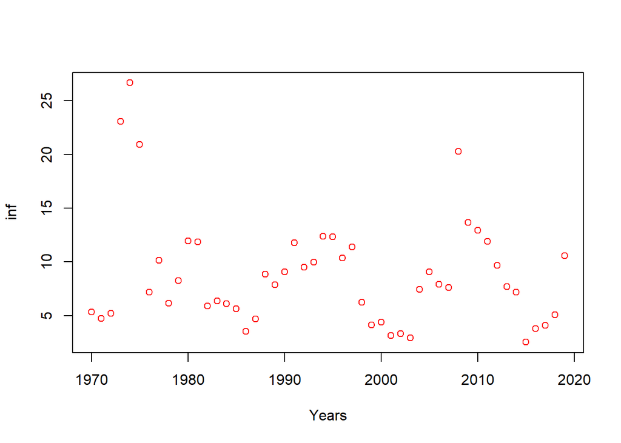

```r
with(subset_data, plot(Years,inf, col = "red"))
```

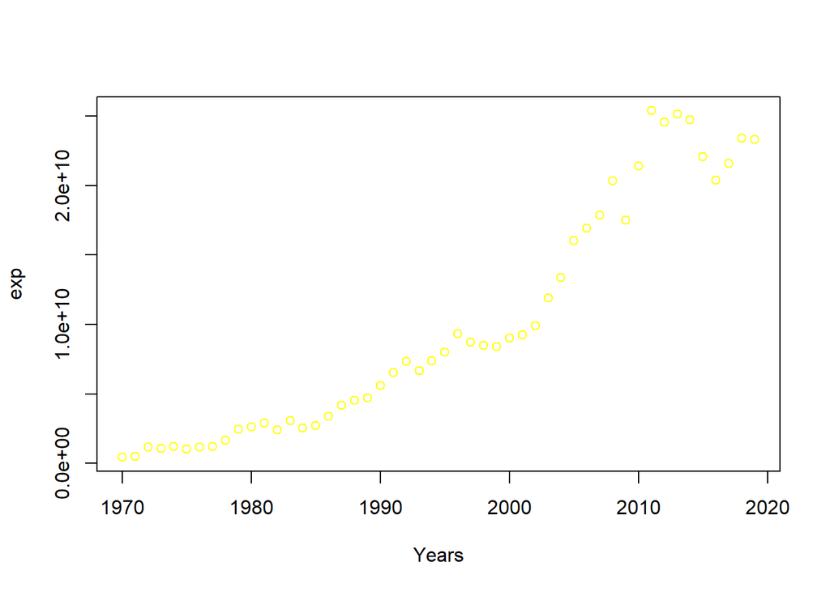

```r
with(subset_data, plot(Years,exp, col = "yellow"))
```

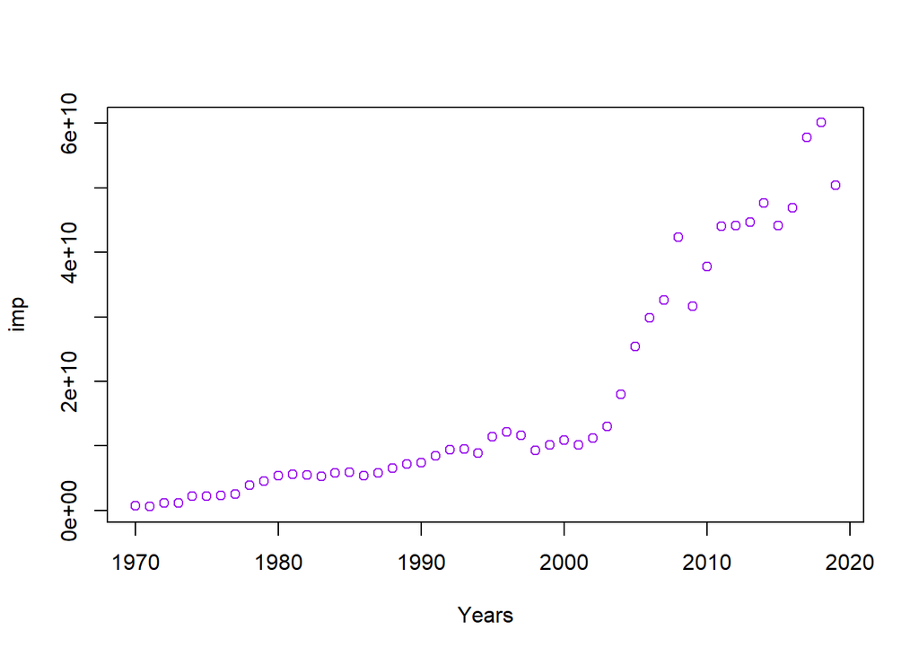

```r
with(subset_data, plot(Years,imp, col = "purple"))
```

### Regression Modelling

Some of the data points were removed due to NaN values. For the regression, we have annual data from 1971-2019 except for the values of 1973 and 1974.

The regression model is as follows: ∆logFDI = β0 + β1∆DomCre(%) + β2∆logMimp + β3∆logMexp + β4∆Inf%

Variance inflation factors are under control for all explanatory variables. There is no evidence of multicollinearity in the data. Model captures 38.57% of variance in change if foreign direct investments. Overall model is significant, however, not all explanatory variables are significant. Model cannot be used for inference. Further developments are required!

```r
fdi_lgc <- diff(log(subset_data$fdi), lag = 1)
subset_data <- cbind(subset_data,c(0,fdi_lgc))

dom.cre_c <- diff(subset_data$dom.cre, lag = 1)
subset_data <- cbind(subset_data,c(0,dom.cre_c))

imp_lgc <- diff(log(subset_data$imp), lag = 1)
subset_data <- cbind(subset_data,c(0,imp_lgc))

exp_lgc <- diff(log(subset_data$exp), lag = 1)
subset_data <- cbind(subset_data,c(0,exp_lgc))

inf_c <- diff(subset_data$inf, lag = 1)
subset_data <- cbind(subset_data,c(0,inf_c))

names(subset_data) <- c("Years", "fdi", "dom.cre", "inf", "exp",
                        "imp", "fdi_lgc", "dom.cre_c", "imp_lgc", "exp_lgc", "inf_c")
names(subset_data)
```

```
##  [1] "Years"     "fdi"       "dom.cre"   "inf"       "exp"       "imp"
##  [7] "fdi_lgc"   "dom.cre_c" "imp_lgc"   "exp_lgc"   "inf_c"
```

```r
subset_data2 <- subset_data %>%
        filter(Years >= 1971 & Years != 1973 & Years != 1974) %>%
        select(fdi_lgc,dom.cre_c,imp_lgc,exp_lgc,inf_c)

model <- lm(fdi_lgc~dom.cre_c+imp_lgc+exp_lgc+inf_c, data = subset_data2)
summary(model)
```

```
##
## Call:
## lm(formula = fdi_lgc ~ dom.cre_c + imp_lgc + exp_lgc + inf_c,
##     data = subset_data2)
##
## Residuals:
##      Min       1Q   Median       3Q      Max
## -2.19882 -0.34087  0.04183  0.31330  1.85910
##
## Coefficients:
##              Estimate Std. Error t value Pr(>|t|)
## (Intercept) -0.067780   0.115071  -0.589 0.558998
## dom.cre_c    0.035692   0.053199   0.671 0.505943
## imp_lgc      3.293525   0.805545   4.089 0.000192 ***
## exp_lgc     -0.615299   0.778477  -0.790 0.433741
## inf_c        0.002136   0.027092   0.079 0.937543
## ---
## Signif. codes:  0 '***' 0.001 '**' 0.01 '*' 0.05 '.' 0.1 ' ' 1
##
## Residual standard error: 0.6697 on 42 degrees of freedom
## Multiple R-squared:  0.3857, Adjusted R-squared:  0.3272
## F-statistic: 6.592 on 4 and 42 DF,  p-value: 0.0003277
```

```r
vif(model)
```

```
## dom.cre_c   imp_lgc   exp_lgc     inf_c
##  1.161529  1.795550  1.778086  1.100941
```

I hope this work was worthy of your attention. The model here is not fit for any inference. However, I do plan to further deepen my understanding on stochastic processes soon and further develop the model. I have recently started to learn R Programming language and open to any suggestions for improving my work.

Thank You!